# act_report

## Report: act_report

> **by EMMANUEL NCUBE**

## Introduction

This report is part of the fulfillment of the Udacity Data Science Nanodegree, and aims to present relevant insights from the [WeRateDogs](https://twitter.com/dog_rates) twitter account.

[figure not shown]

[WeRateDogs](https://twitter.com/dog_rates) is a twitter account that rates people's dogs with a humorous comment about the dog. The account was started in 2015 by college student Matt Nelson, and has received international media attention for its popularity.[WeRateDogs](https://twitter.com/dog_rates) asks people to send photos of their dogs, then tweets selected photos rating and a humorous comment. Dogs are rated on a scale of one to ten, but are invariably given ratings in excess of the maximum, such as "13/10". Popular posts are re-posted on Instagram and Facebook. Check more information [here](https://en.wikipedia.org/wiki/WeRateDogs).

The data from [WeRateDogs](https://twitter.com/dog_rates) twitter archive was collected and cleaned. A summary [Data Wrangle Report](https://viewf6b31853.udacity-student-workspaces.com/view/wrangle_report.html) was also prepared. The main partly clean dataset for this analysis is a csv file named [twitter_archive_master](https://viewf6b31853.udacity-student-workspaces.com/edit/twitter_archive_master.csv) which is a combination three datasets; archive_clean_master.csv, image_predictions_master.csv and tweets clean.

```python
from IPython.display import HTML

HTML('''<script>
code_show=true;
function code_toggle() {
 if (code_show){
 $('div.input').hide();
 } else {
 $('div.input').show();
 }
 code_show = !code_show
}
$( document ).ready(code_toggle);
</script>
<form action="javascript:code_toggle()"><input type="submit" value="Click here to toggle on/off the raw code."></form>''')
```

### 1. The top 5 popular dog names

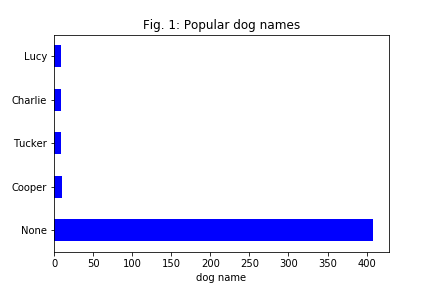

```python
from IPython import display
display.Image("./images/dog_name.png")
```

### 2. Highly retweeted and favorite dog stage.

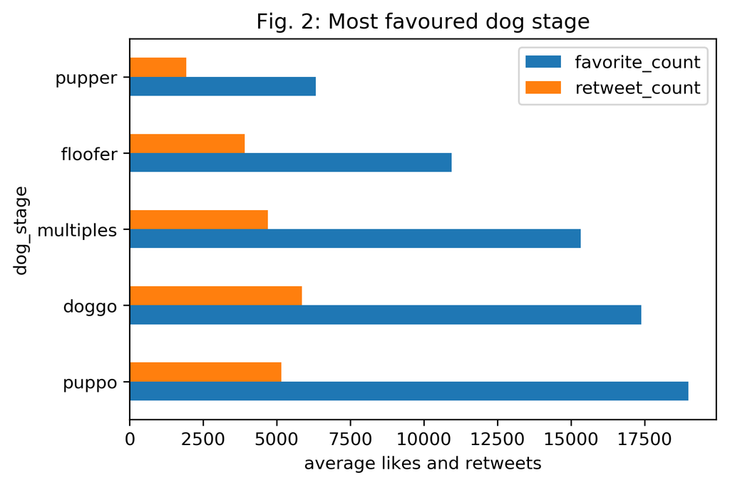

```python
display.Image("./images/favorite_retweet.png", embed=True, width=500, height=250)
```

> **Meet [Sebastian](https://twitter.com/dog_rates/status/874012996292530176), an example of a puppo.**

[figure not shown]

### 3. Favorite dog breed

> **As given in Fig. 3 below, 5 Highly rated dog breeds include:**
> 1. Golden Retriever
> 2. Labrador Retriever
> 3. Pembroke
> 4. Chihuahua
> 5. French Bulldog

> According to the American Kernel Club article [The 25 Most Popular Dog Breeds of 2023](https://www.akc.org/expert-advice/dog-breeds/most-popular-dog-breeds-of-2021/), Golden Retriever and Labarador Retriever are part of the top 5 most popular and must love dog breeds.Golden and Labrador Retrievers can be trained as guide dogs and therapy dogs, and may compete in obedience trials and other dog sports. They are happy and outgoing and love to retrieve balls, frisbees and just about anything you toss out. No wonder these dog breeds are the most loved.

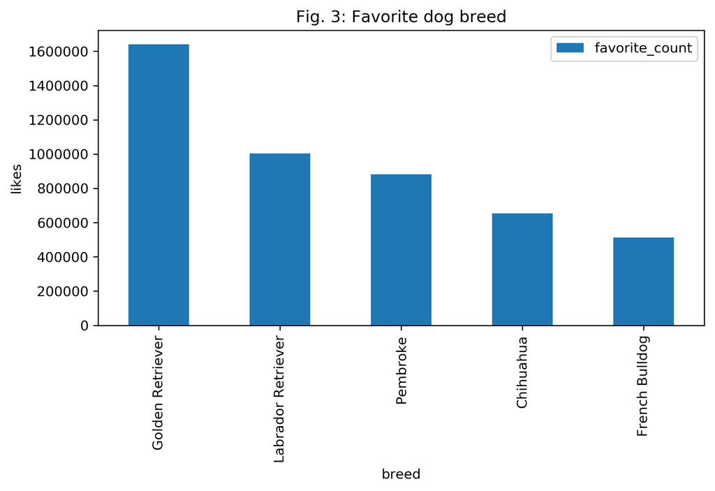

```python
display.Image("./images/breed_rating.png", embed=True, width=500, height=250)
```

[output not shown]

### 4. Relationship between likes and retweets

> A strong Correlation (Spearman's rho: 0.93) between retweets and likes among all the tweets in the sample, shows a strong relationship. Fig. 4 points to the same thought.

[figure not shown]

```python
display.Image("./images/retweet_vs_favorite.png", embed=True, width=500, height=250)
```

### 5. Device a tweet was tweeted from.

> Most twitter activity on the WeRateDogs twitter account is accessed via twitter for iphone app followed by Twitter Web Client. Elon Musk the new owner of Twitter suggested removing the line that says what device a tweet was tweeted.

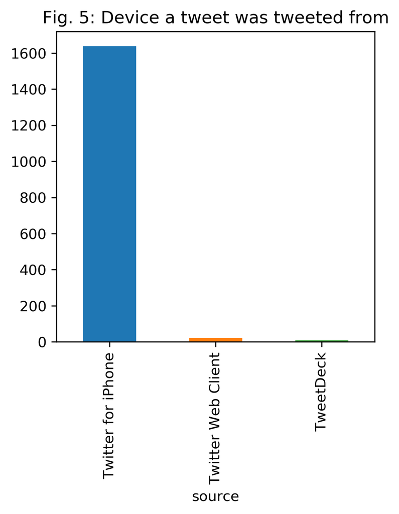

```python
display.Image("./images/source_count.png", embed=True, width=400, height=200)
```

### Disclaimer

> Assessing and cleaning the entire dataset completely would require a lot of time, and was not necessary to practice and demonstrate skills in data wrangling. Therefore, the requirements of this project were only to assess and clean at least 8 quality issues and at least 2 tidiness issues in this dataset.